# Homework 2 - INFSCI 2160: Data Mining

## 26 Sep 2017

### Hyunseok Choi (hyc23@pitt.edu) | Meng Li (mel165@pitt.edu) | Junchao Mei (jum68@pitt.edu)

#### The objective is to predict the binary (TARGET_Adjusted) and continuous (RISK_Adjustment) target variables.

```r
# Load data
data.file = '/home/nbuser/library/audit.csv'
ad = read.csv(data.file , header = TRUE , sep = ',')
```

### 1) Read the data description on DMR p.297. Identify and report response variable and predictors.

>It has two response variables *RISK_Adjustment* and *TARGET_Adjusted*. RISK_Adjustment is a continuous variable, and TARGET_Adjusted is a binary variable which is consisted of 1 and 0.

>The other variables such as Age, Employment, Education, Marital, Occupation, Income, Gender, Deductions, and Hours are predictors.

>ID is a unique identifier for each record, so it's not considered as a predictor.

### 2) Explore the dataset, and generate both statistical and graphical summary with respect to the numerical and categorical variables. Provide analysis similar to HW1 (2b)–(2e)..

#### a) Generate a summary table for the data. For each numerical variable, list: variable name, mean, median, 1st quartile, 3rd quartile, and standard deviation.

> Since the response variable, TARGET_Adjusted, was recognized as a continuous variable at first, I set it as a categorical variable.

```r
ad$TARGET_Adjusted <- as.factor(ad$TARGET_Adjusted) # set it as binary variable.(factor)

dim(ad)
summary(ad)
# Summary data for 'ID' is meaningless because it's only an identifier.

# get the values of standard deviation numerical variables
cat(sprintf("Standard deviation: \n Age: %f\n Income: %f\n Deductions: %f\n Hours:%f\n RIST_Adjustment: %f",
        sd(ad$Age),
        sd(ad$Income),
        sd(ad$Deductions),
        sd(ad$Hours),
        sd(ad$RISK_Adjustment)
       ))
```

1. 2000

2. 12

```
       ID               Age             Employment        Education
 Min.   :1004641   Min.   :17.00   Private   :1411   HSgrad    :660
 1st Qu.:3437052   1st Qu.:28.00   Consultant: 148   College   :442
 Median :5638451   Median :37.00   PSLocal   : 119   Bachelor  :345
 Mean   :5624348   Mean   :38.62   SelfEmp   :  79   Master    :102
 3rd Qu.:7876535   3rd Qu.:48.00   PSState   :  72   Vocational: 86
 Max.   :9996101   Max.   :90.00   (Other)   :  71   Yr11      : 74
                                   NA's      : 100   (Other)   :291
                  Marital           Occupation      Income
 Absent               :669   Executive   :289   Min.   :   609.7
 Divorced             :266   Professional:247   1st Qu.: 34433.1
 Married              :917   Clerical    :232   Median : 59768.9
 Married-spouse-absent: 22   Repair      :225   Mean   : 84688.5
 Unmarried            : 67   Service     :210   3rd Qu.:113842.9
 Widowed              : 59   (Other)     :696   Max.   :481259.5
                             NA's        :101
    Gender       Deductions          Hours       RISK_Adjustment
 Female: 632   Min.   :   0.00   Min.   : 1.00   Min.   : -1453
 Male  :1368   1st Qu.:   0.00   1st Qu.:38.00   1st Qu.:     0
               Median :   0.00   Median :40.00   Median :     0
               Mean   :  67.57   Mean   :40.07   Mean   :  2021
               3rd Qu.:   0.00   3rd Qu.:45.00   3rd Qu.:     0
               Max.   :2904.00   Max.   :99.00   Max.   :112243

 TARGET_Adjusted
 0:1537
 1: 463
```

```
Standard deviation:
 Age: 13.584748
 Income: 69621.644503
 Deductions: 340.704705
 Hours:12.153716
 RIST_Adjustment: 8341.872294
```

```r
# Print observations with missing values
print(colnames(ad)[colSums(is.na(ad)) > 0])
```

```
[1] "Employment" "Occupation"
```

> Those features have NA values. By the textbook's definition, it's not explained in detail and the number of the observations with NA values are not significant in this dataset. So we determined to omit the rows with NAs.

```r
# delete rows with the value of "NA"
ad=na.omit(ad)
# check missing value again
any(is.na(ad))
print(dim(ad)) # Now we have 1899 observations (reduced from original 2000 observations)
```

FALSE

```
[1] 1899   12
```

```r
summary(ad$Employment)
summary(ad$Occupation)
```

**Consultant**

148

**PSFederal**

69

**PSLocal**

119

**PSState**

72

**Private**

1411

**SelfEmp**

79

**Unemployed**

0

**Volunteer**

1

**Cleaner**

91

**Clerical**

232

**Executive**

289

**Farming**

58

**Home**

5

**Machinist**

139

**Military**

1

**Professional**

247

**Protective**

40

**Repair**

225

**Sales**

206

**Service**

210

**Support**

49

**Transport**

107

> We found EmploymentUnemployed, EmploymentVolunteer, and OccupationMilitary can distort the result because they have only 0 or 1 obervation.

```r
## Singular Values Processing
# delete the unmeaningful observations:
ad <- ad[(ad$Employment != 'Unemployed'),]; dim(ad)
ad <- ad[(ad$Employment != 'Volunteer'),]; dim(ad)
ad <- ad[(ad$Occupation != 'Military'),]; dim(ad)
# Drop unused levels
ad$Occupation <- droplevels(ad$Occupation)
levels(ad$Occupation)
ad$Employment <- droplevels(ad$Employment)
levels(ad$Employment)
```

1. 1899

2. 12

1. 1898

2. 12

1. 1897

2. 12

1. 'Cleaner'

2. 'Clerical'

3. 'Executive'

4. 'Farming'

5. 'Home'

6. 'Machinist'

7. 'Professional'

8. 'Protective'

9. 'Repair'

10. 'Sales'

11. 'Service'

12. 'Support'

13. 'Transport'

1. 'Consultant'

2. 'PSFederal'

3. 'PSLocal'

4. 'PSState'

5. 'Private'

6. 'SelfEmp'

```r
summary(ad$Employment)
summary(ad$Occupation)
```

**Consultant**

148

**PSFederal**

68

**PSLocal**

119

**PSState**

72

**Private**

1411

**SelfEmp**

79

**Cleaner**

91

**Clerical**

232

**Executive**

289

**Farming**

57

**Home**

5

**Machinist**

139

**Professional**

247

**Protective**

40

**Repair**

225

**Sales**

206

**Service**

210

**Support**

49

**Transport**

107

#### b) For numerical variables, plot the density distribution. Describe whether the variable has a normal distribution or certain type of skew distribution.

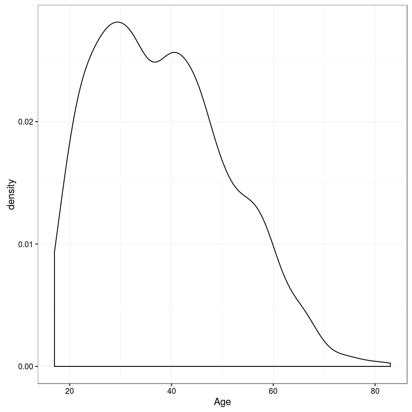

```r
library('ggplot2')
theme_set(theme_bw()) # set default theme with white background
ggplot(ad, aes(x=Age)) + geom_density()
```

Based on the density distribution, *Age* is a skewed distribution.

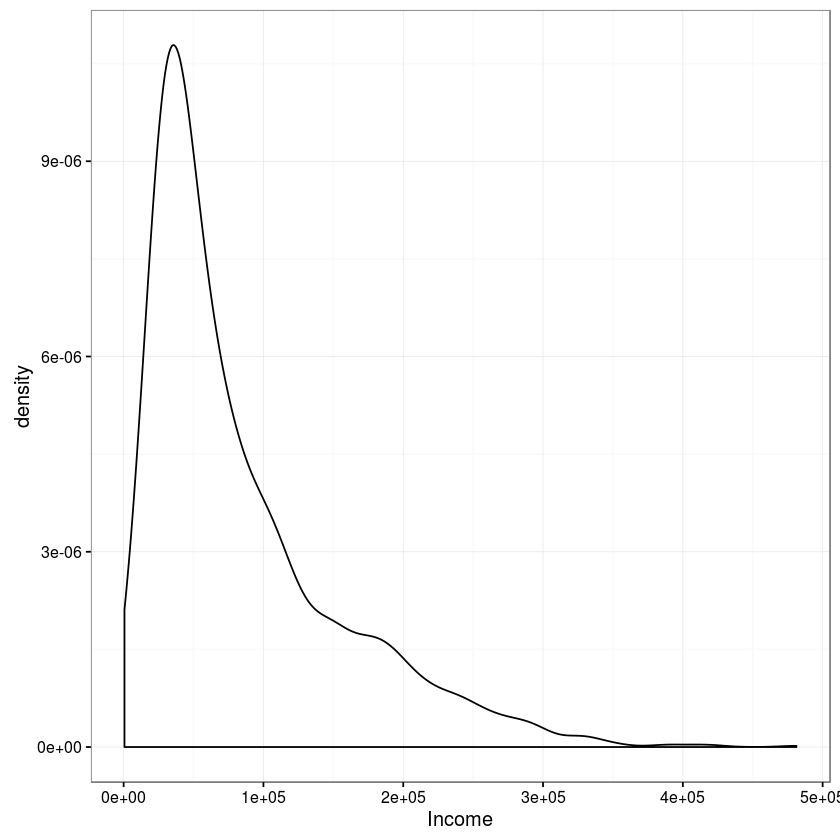

```r
ggplot(ad, aes(x=Income)) + geom_density()
```

Based on the density distribution, *Income* is a right skewed unimodal distribution.

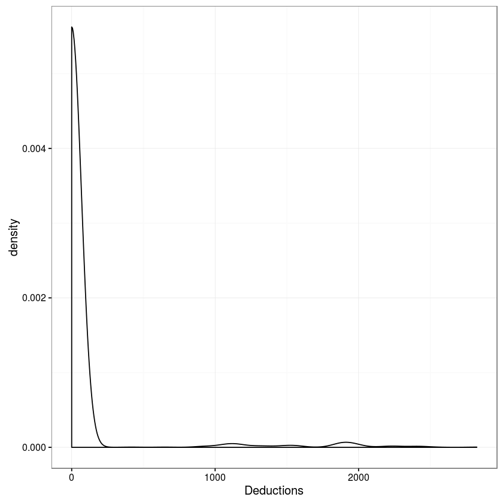

```r
ggplot(ad, aes(x=Deductions)) + geom_density()
```

Based on the density distribution, *Deductions* is a right skewed unimodal distribution with a thin tail.

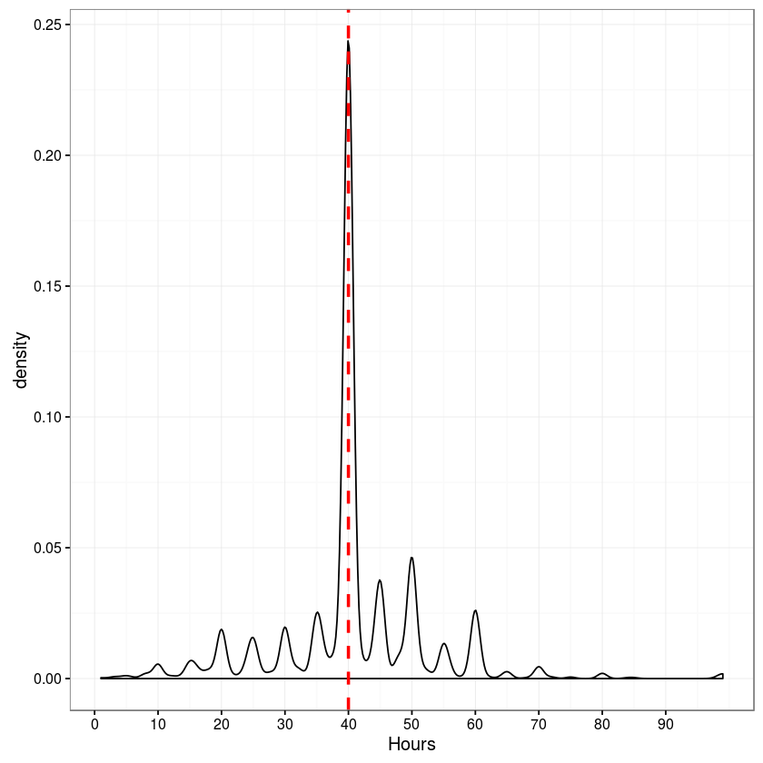

```r
ggplot(ad, aes(x=Hours)) + geom_density() +
    scale_x_continuous(breaks=round(seq(0, max(ad$Hours), by=10), 1)) + # Changed X axis interval to see its peak value
    geom_vline(xintercept = median(ad$Hours), size = 1, color = 'red', linetype='dashed')
```

>Based on the density distribution, *Hours* is a multimodal distribution. It is approximately symmetric at its median 40 (although, it should be mean instead of median by definition). >However, its values are integers(not continuous numbers), and density distribution in this case can somewhat misrepresent its distribution. It's because density function works less well with discrete values than continuous ones.

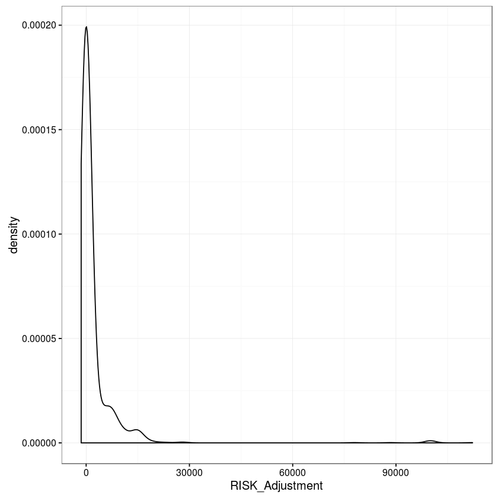

```r
ggplot(ad, aes(x=RISK_Adjustment)) + geom_density() +
  scale_x_continuous(limits=c(min(ad$RISK_Adjustment),max(ad$RISK_Adjustment)) )
```

> Based on the density distribution, *RISK_Adjustment* is a right skewed unimodal distribution with a thin tail. If you exclude the ten outlier values which is greater than 90000, the skewness is not that high.

#### c) For each categorical predictor, generate the conditional histogram plot of response variable.

> I will print out the conditional histogram for each categorical predictor. I pass each predictor to *param*. The first histograms describe frequency of *TARGET_Adjusted* by each predictor value. Since it's useful to compare across the values, the second histograms describe proportion of *TARGET_Adjusted* by each predictor value. The third histograms describe frequency of *RISK_Adjustment* based on each predictor value.

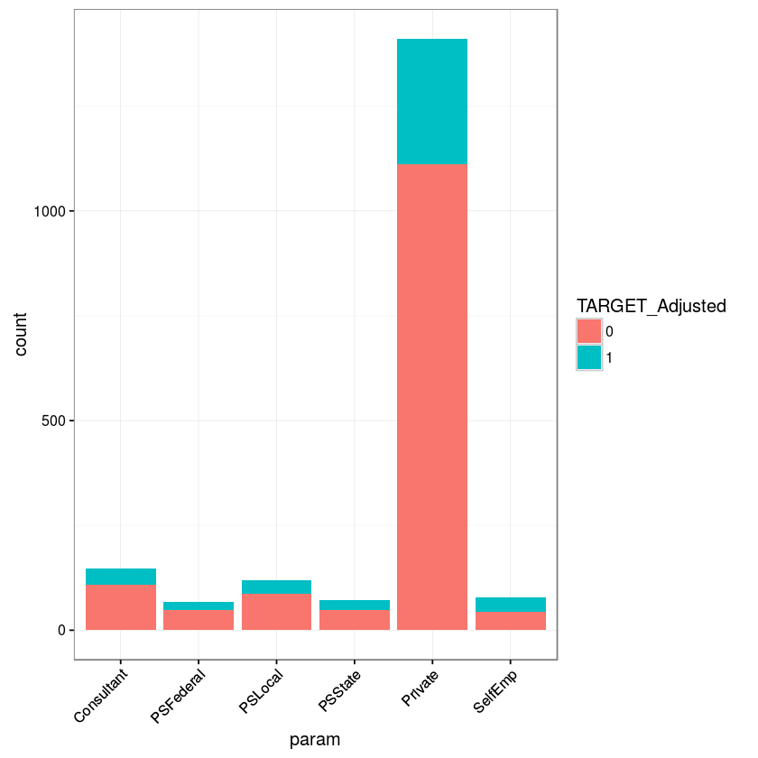

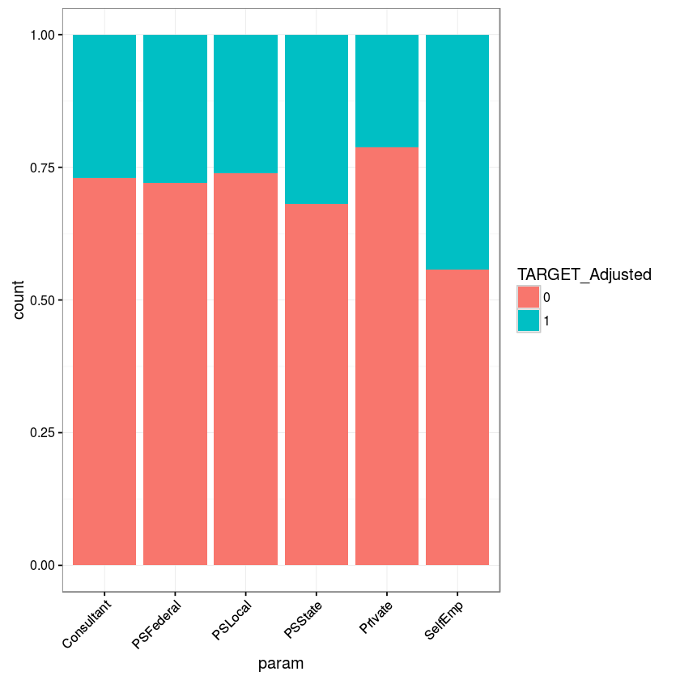

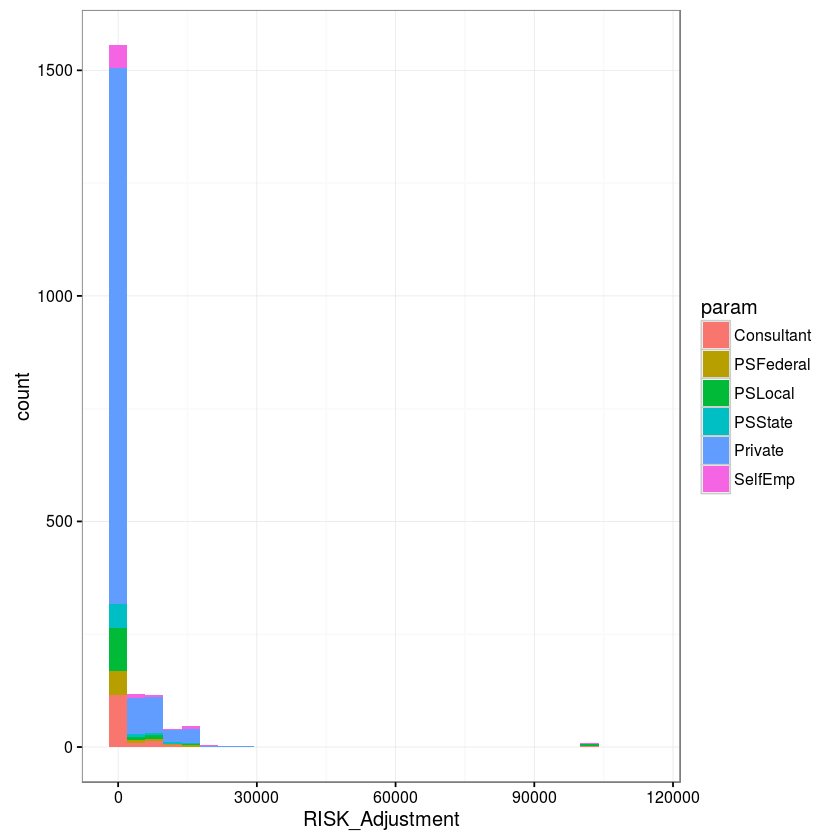

```r
param = ad$Employment

ggplot(ad, aes(param, ..count..)) + geom_bar(aes(fill=TARGET_Adjusted), position='stack')+
    theme(axis.text.x = element_text(angle = 45, hjust = 1))
ggplot(ad, aes(param, ..count..)) + geom_bar(aes(fill=TARGET_Adjusted), position='fill')+
    theme(axis.text.x = element_text(angle = 45, hjust = 1))
ggplot(ad, aes(RISK_Adjustment, fill=param)) + geom_histogram()
```

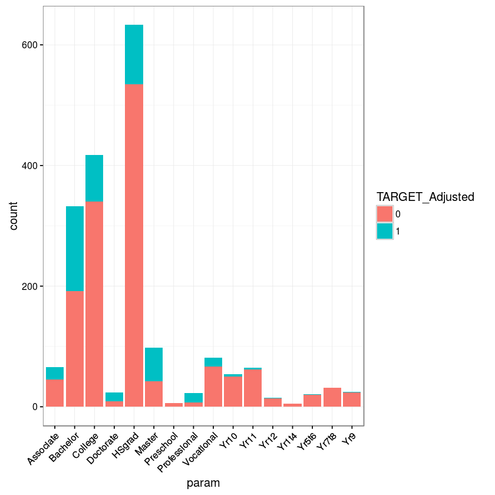

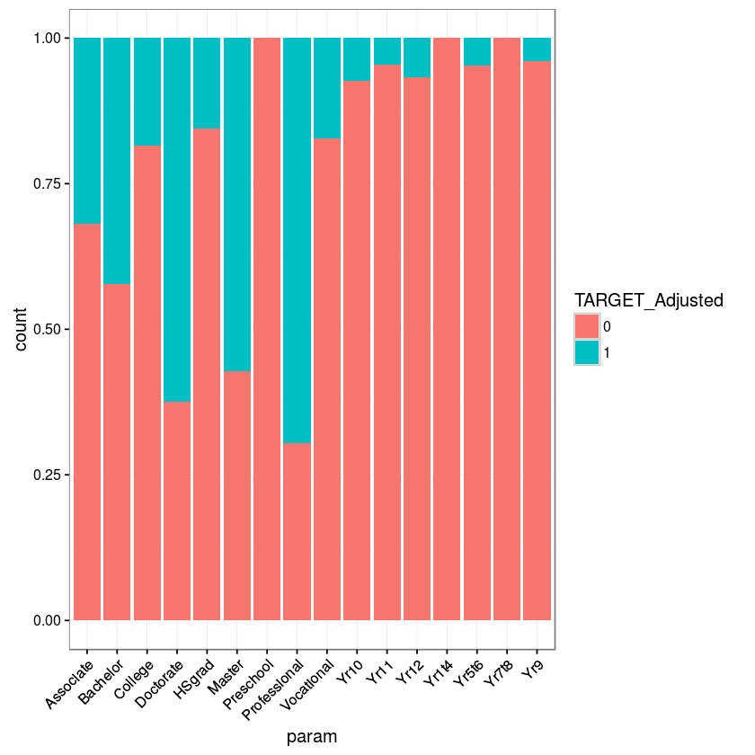

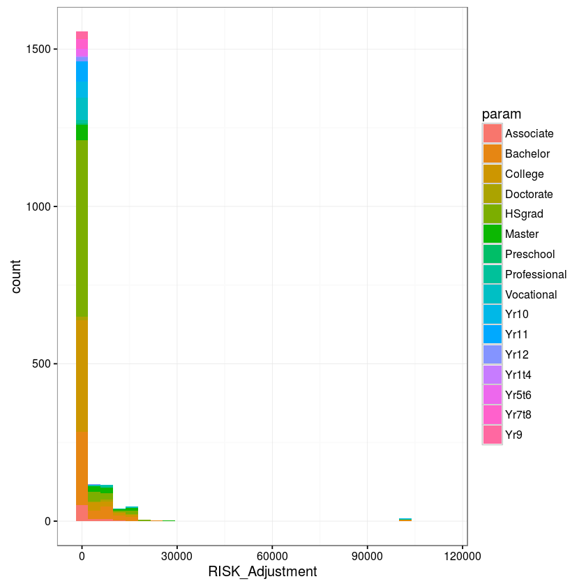

```r
param = ad$Education

ggplot(ad, aes(param, ..count..)) + geom_bar(aes(fill=TARGET_Adjusted), position='stack')+
    theme(axis.text.x = element_text(angle = 45, hjust = 1))
ggplot(ad, aes(param, ..count..)) + geom_bar(aes(fill=TARGET_Adjusted), position='fill')+
    theme(axis.text.x = element_text(angle = 45, hjust = 1))
ggplot(ad, aes(RISK_Adjustment, fill=param)) + geom_histogram()
```

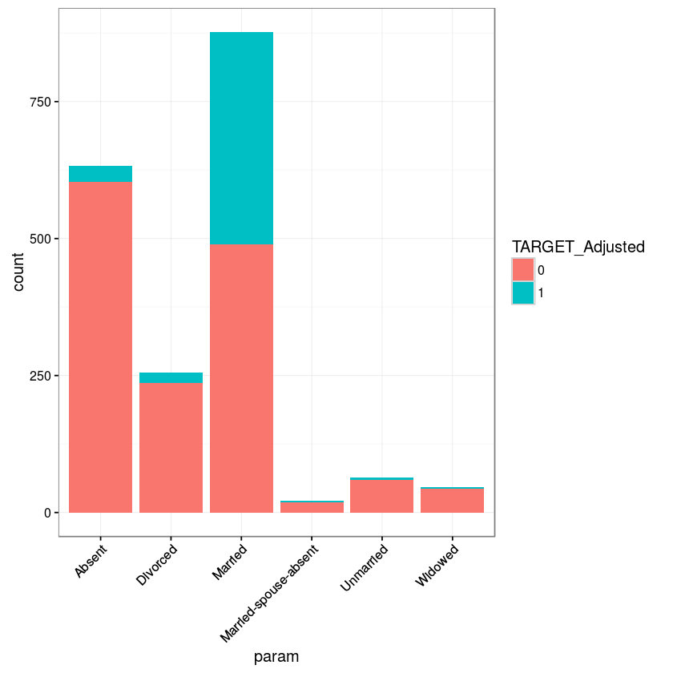

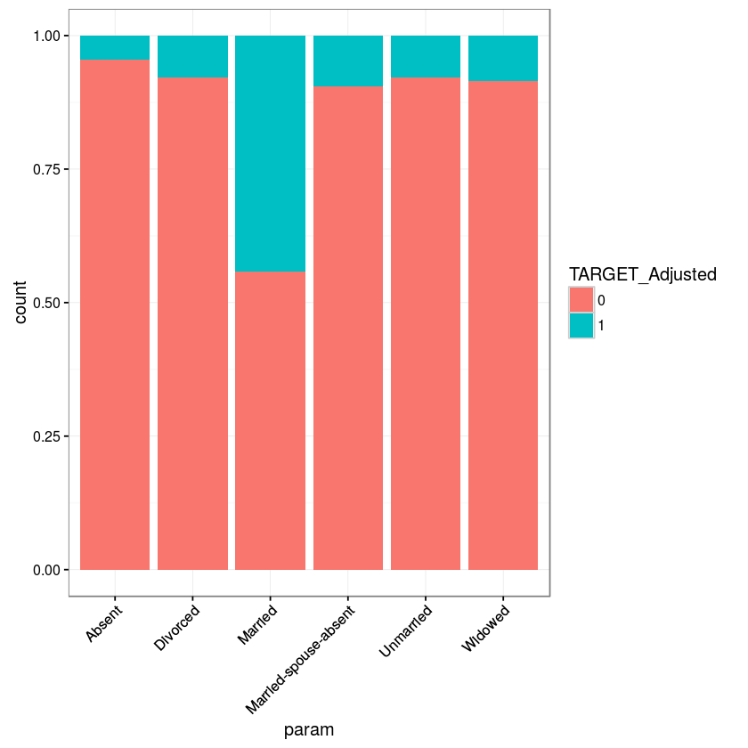

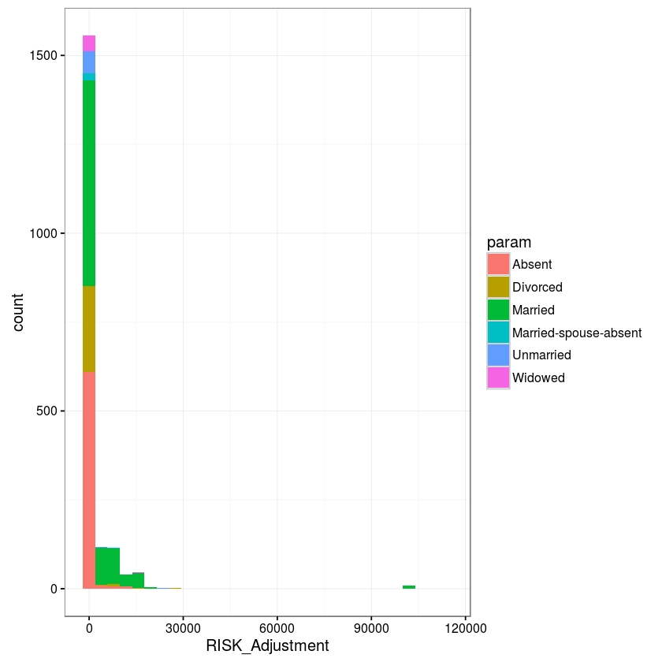

```r
param = ad$Marital
ggplot(ad, aes(param, ..count..)) + geom_bar(aes(fill=TARGET_Adjusted), position='stack')+
    theme(axis.text.x = element_text(angle = 45, hjust = 1))
ggplot(ad, aes(param, ..count..)) + geom_bar(aes(fill=TARGET_Adjusted), position='fill')+
    theme(axis.text.x = element_text(angle = 45, hjust = 1))
ggplot(ad, aes(RISK_Adjustment, fill=param)) + geom_histogram()
```

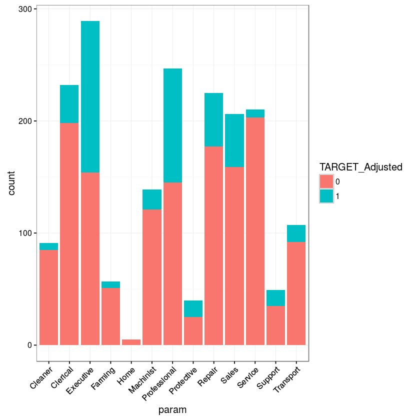

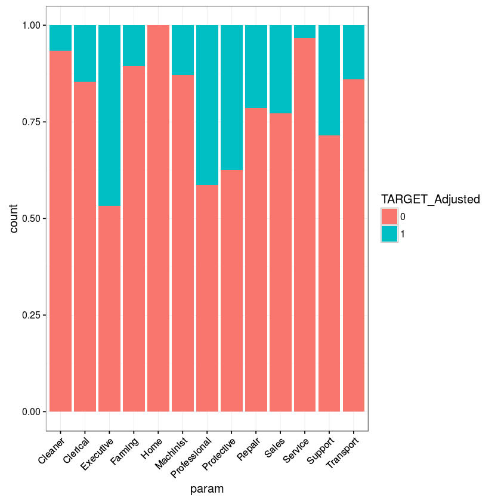

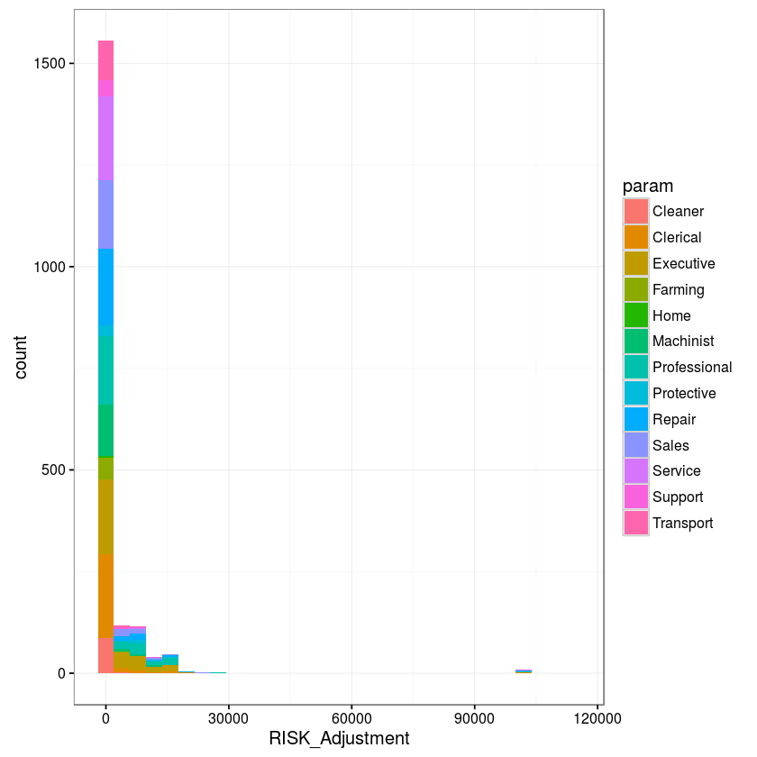

```r
param = ad$Occupation

ggplot(ad, aes(param, ..count..)) + geom_bar(aes(fill=TARGET_Adjusted), position='stack')+
    theme(axis.text.x = element_text(angle = 45, hjust = 1))
ggplot(ad, aes(param, ..count..)) + geom_bar(aes(fill=TARGET_Adjusted), position='fill')+
    theme(axis.text.x = element_text(angle = 45, hjust = 1))
ggplot(ad, aes(RISK_Adjustment, fill=param)) + geom_histogram()
```

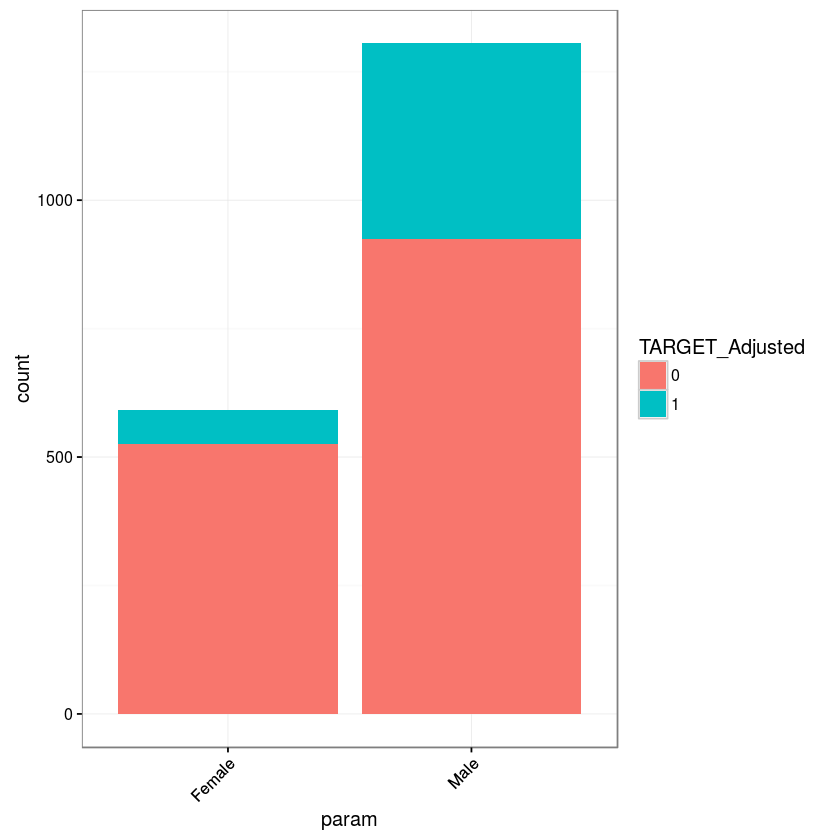

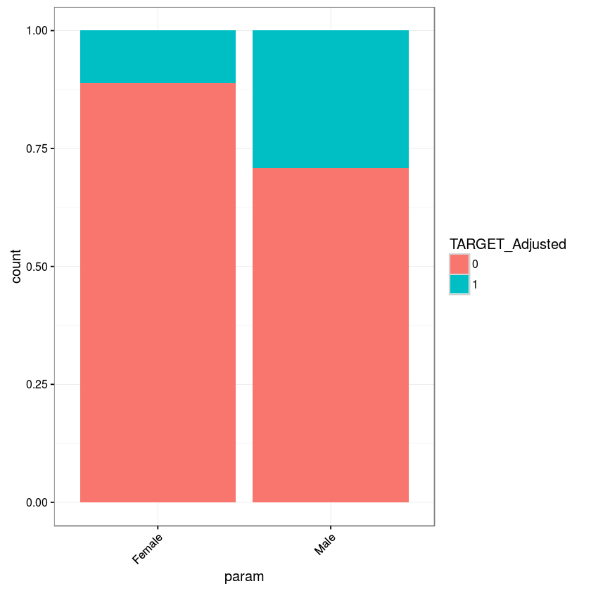

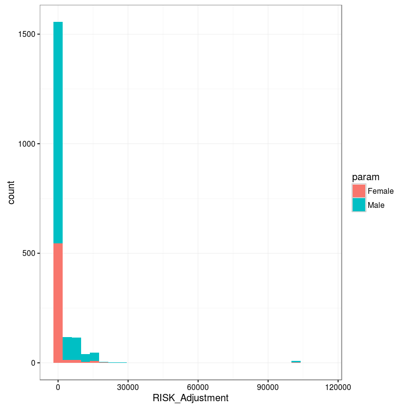

```r
param = ad$Gender

ggplot(ad, aes(param, ..count..)) + geom_bar(aes(fill=TARGET_Adjusted), position='stack')+
    theme(axis.text.x = element_text(angle = 45, hjust = 1))
ggplot(ad, aes(param, ..count..)) + geom_bar(aes(fill=TARGET_Adjusted), position='fill')+
    theme(axis.text.x = element_text(angle = 45, hjust = 1))
ggplot(ad, aes(RISK_Adjustment, fill=param)) + geom_histogram()
```

### 3) Apply logistic regression analysis to predict TARGET_Adjusted. Evaluate the models through cross-validation and on holdout samples. Interpret the effect of the predictors.

#### a) Implement a 10-fold cross-validation scheme by splitting the data into training and testing sets. Use the training set to train a logistic regression model to predict the response variable. Examine the performance of different models by varying the number of predictors. Report the performance of the models on testing set using proper measures (accuracy, precision, recall, F1, AUC) and plots (ROC, lift).

```r
# import required libraries
library(caret)
library(pROC)
set.seed(777)
```

```r
# use facor levels that can be used as valid R variable name
levels(ad$TARGET_Adjusted) = c("zero","one")
```

> Model 1

```r
#### train model1
# predictors: Age+Education+Marital+Occupation+Income+Gender+Deductions+Hours+Employment
model = train(TARGET_Adjusted~Age+Education+Marital+Occupation+Income+Gender+Deductions+Hours+Employment,
              data=ad,method='glm',family=binomial(link='logit'),trControl=trainControl(
                method="cv",number=10,savePredictions = TRUE,classProbs=TRUE))
```

```
[1] "Confusion Matrix:"
```

```
       zero  one
  zero 1334  116
  one   199  248
```

```
-----------------------------------------------------
 Accuracy: 0.833948
 Precision: 0.870189
 Recall: 0.920000
 F1: 0.894402
 AUC: 0.878503
-----------------------------------------------------
```

```
Call:
roc.default(response = truevalue$model.pred.obs, predictor = model$pred$zero)

Data: model$pred$zero in 1450 controls (truevalue$model.pred.obs 0) > 447 cases (truevalue$model.pred.obs 1).
Area under the curve: 0.8785
```

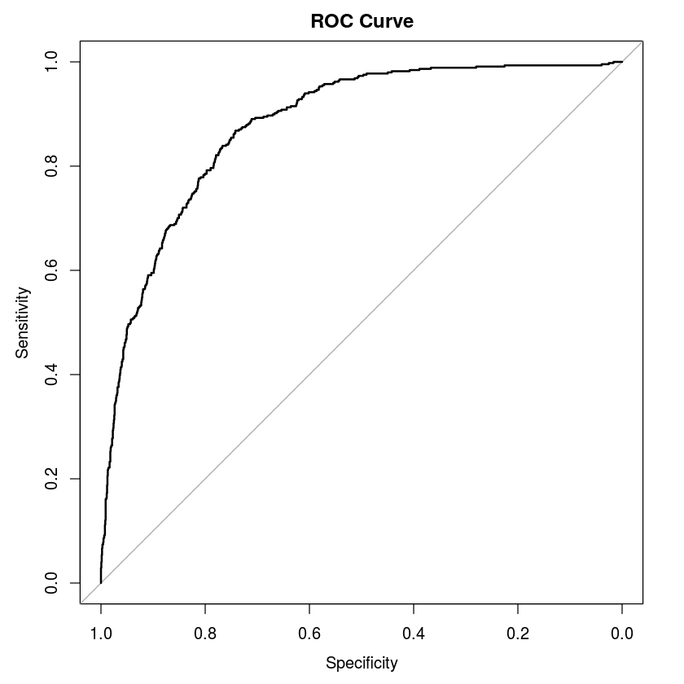

```r
#### model evaluation
# confusionMatrix
cm = table(model$pred$obs,model$pred$pred)
print("Confusion Matrix:")
cm
# calcute the accuracy,precision,recall,F1 value
accuracy = (cm[1,1]+cm[2,2])/(cm[1,1]+cm[1,2]+cm[2,1]+cm[2,2])
precision = cm[1,1]/(cm[1,1]+cm[2,1])
recall = cm[1,1]/(cm[1,1]+cm[1,2])
f1score = 2*precision*recall/(precision+recall)
# AUC
truevalue=data.frame(model$pred$obs)
levels(truevalue$model.pred.obs)=c(0,1)
# use pROC package to calculate AUC value
auc = auc(roc(truevalue$model.pred.obs,model$pred$zero))

#print
cat(sprintf("-----------------------------------------------------\n Accuracy: %f\n Precision: %f\n Recall: %f\n F1: %f\n AUC: %f\n-----------------------------------------------------\n",
            accuracy,precision,recall,f1score,auc))

#plot ROC Curve
plot(roc(truevalue$model.pred.obs,model$pred$zero),main='ROC Curve')
```

```r
# #plot lift chart
# notrank=cbind(data.frame(truevalue$model.pred.obs),data.frame(model$pred$zero))
# colnames(notrank)=c('true','pred')
# rank = as.data.frame(notrank[order(data.frame(model$pred$zero),decreasing=TRUE),])

# num = length(model$pred$zero)
# ax = dim(num)
# ay.true=dim(num)
# ay.pred=dim(num)
# ax[1]=1
# ay.true[1]=mean(model$pred$zero)
# ay.true[1]
# ay.pred[1]=rank$true[1]
# for(i in 2:num){
#     ax[i]=i
#     ay.true[i]=mean(model$pred$zero)*i
#     ay.pred[i]=ay.pred[i-1]+rank$true[i]
# }
# plot(ax,ay.pred,xlab='number of cases',ylab='number of successes',main='Lift Chart')
```